# swirl Lesson 1: CaseStudy

CaseStudy. (Slides for this and other Data Science courses may be found at github https://github.com/DataScienceSpecialization/courses/. If you care to use them, they must be downloaded as a zip file and viewed locally. This lesson corresponds to 04_ExploratoryAnalysis/CaseStudy.)

In this lesson we’ll apply some of the techniques we learned in this course to study air pollution data, specifically particulate matter (we’ll call it pm25 sometimes), collected by the U.S. Environmental Protection Agency. This website https://www.health.ny.gov/environmental/indoors/air/pmq_a.htm from New York State offers some basic information on this topic if you’re interested.

Particulate matter (less than 2.5 microns in diameter) is a fancy name for dust, and breathing in dust might pose health hazards to the population. We’ll study data from two years, 1999 (when monitoring of particulate matter started) and 2012. Our goal is to see if there’s been a noticeable decline in this type of air pollution between these two years.

We’ve read in 2 large zipped files for you using the R command read.table (which is smart enough to unzip the files). We stored the 1999 data in the array pm0 for you. Run the R command dim now to see its dimensions.

```r
pathtofile <- function(fileName){
    mypath <- file.path(fileName)
}

my1999 <- pathtofile("./data/airData1999.txt.gz")
pm0 <- read.table(my1999, comment.char="#", header=FALSE, sep="|", na.strings="")
```

```r
dim(pm0)
```

```
[1] 117421      5
```

We see that pm0 has over 117000 lines, each containing 5 columns. In the original file, at the EPA website, each row had 28 columns, but since we’ll be using only a few of these, we’ve created and read in a somewhat smaller file. Run head on pm0 now to see what the first few lines look like.

```r
head(pm0)
```

|  | V1 | V2 | V3 | V4 | V5 |
| --- | --- | --- | --- | --- | --- |
| 1 | 1 | 27 | 1 | 19990103 | NA |
| 2 | 1 | 27 | 1 | 19990106 | NA |
| 3 | 1 | 27 | 1 | 19990109 | NA |
| 4 | 1 | 27 | 1 | 19990112 | 8.841 |
| 5 | 1 | 27 | 1 | 19990115 | 14.920 |
| 6 | 1 | 27 | 1 | 19990118 | 3.878 |

We see there’s some missing data, but we won’t worry about that now. We also see that the column names, V1, V2, etc., are not informative. However, we know that the first line of the original file (a comment) explained what information the columns contained.

We created the variable cnames containing the 28 column names of the original file. Take a look at the column names now.

```r
cnames <- "# RD|Action Code|State Code|County Code|Site ID|Parameter|POC|Sample Duration|Unit|Method|Date|Start Time|Sample Value|Null Data Code|Sampling Frequency|Monitor Protocol (MP) ID|Qualifier - 1|Qualifier - 2|Qualifier - 3|Qualifier - 4|Qualifier - 5|Qualifier - 6|Qualifier - 7|Qualifier - 8|Qualifier - 9|Qualifier - 10|Alternate Method Detectable Limit|Uncertainty"
```

```r
cnames
```

```
[1] "# RD|Action Code|State Code|County Code|Site ID|Parameter|POC|Sample Duration|Unit|Method|Date|Start Time|Sample Value|Null Data Code|Sampling Frequency|Monitor Protocol (MP) ID|Qualifier - 1|Qualifier - 2|Qualifier - 3|Qualifier - 4|Qualifier - 5|Qualifier - 6|Qualifier - 7|Qualifier - 8|Quali…
```

We see that the 28 column names look all jumbled together even though they’re separated by “|” characters, so let’s fix this. Reassign to cnames the output of a call to strsplit (string split) with 3 arguments. The first is cnames, the pipe symbol ‘|’ is the second (use the quotation marks), and the third is the argument fixed set to TRUE. Try this now.

```r
cnames <- strsplit(cnames, "|", fixed=TRUE)
```

The variable cnames now holds a list of the column headings. Take another look at the column names.

```r
cnames
```

```
[[1]]
 [1] "# RD"                              "Action Code"
 [3] "State Code"                        "County Code"
 [5] "Site ID"                           "Parameter"
 [7] "POC"                               "Sample Duration"
 [9] "Unit"                              "Method"
[11] "Date"                              "Start Time"
[13] "Sample Value"                      "Null Data Code"
[15] "Sampling Frequency"                "Monitor Protocol (MP) ID"
[17] "Qualifier - 1"                     "Qualifier - 2"
[19] "Qualifier - 3"                     "Qualifier - 4"
[21] "Qualifier - 5"                     "Qualifier - 6"
[23] "Qualifier - 7"                     "Qualifier - 8"
[25] "Qualifier - 9"                     "Qualifier - 10"
[27] "Alternate Method Detectable Limit" "Uncertainty"
```

Nice, but we don’t need all these. Assign to names(pm0) the output of a call to the function make.names with cnames[[1]][wcol] as the argument. The variable wcol holds the indices of the 5 columns we selected (from the 28) to use in this lesson, so those are the column names we’ll need. As the name suggests, the function “makes syntactically valid names”.

```r
wcol <- c(3, 4, 5, 11, 13)
```

```r
names(pm0) <- make.names(cnames[[1]][wcol])
```

Now re-run head on pm0 now to see if the column names have been put in place.

```r
head(pm0)
```

|  | State.Code | County.Code | Site.ID | Date | Sample.Value |
| --- | --- | --- | --- | --- | --- |
| 1 | 1 | 27 | 1 | 19990103 | NA |
| 2 | 1 | 27 | 1 | 19990106 | NA |
| 3 | 1 | 27 | 1 | 19990109 | NA |
| 4 | 1 | 27 | 1 | 19990112 | 8.841 |
| 5 | 1 | 27 | 1 | 19990115 | 14.920 |
| 6 | 1 | 27 | 1 | 19990118 | 3.878 |

Now it’s clearer what information each column of pm0 holds. The measurements of particulate matter (pm25) are in the column named Sample.Value. Assign this component of pm0 to the variable x0. Use the m$n notation.

```r
x0 <- pm0$Sample.Value
```

Call the R command str with x0 as its argument to see x0’s structure.

```r
str(x0)
```

```
 num [1:117421] NA NA NA 8.84 14.92 ...
```

We see that x0 is a numeric vector (of length 117000+) with at least the first 3 values missing. Exactly what percentage of values are missing in this vector? Use the R function mean with is.na(x0) as an argument to see what percentage of values are missing (NA) in x0.

```r
mean(is.na(x0))
```

```
[1] 0.1125608
```

So a little over 11% of the 117000+ are missing. We’ll keep that in mind. Now let’s start processing the 2012 data which we stored for you in the array pm1.

We’ll repeat what we did for pm0, except a little more efficiently. First assign the output of make.names(cnames[[1]][wcol]) to names(pm1).

```r
my2012 <- pathtofile("./data/airData2012.txt.gz")
pm1 <- read.table(my2012, comment.char="#", header=FALSE, sep="|", na.strings="")
```

```r
names(pm1) <- make.names(cnames[[1]][wcol])
```

Find the dimensions of pm1 with the command dim.

```r
dim(pm1)
```

```
[1] 1304287       5
```

Wow! Over 1.3 million entries. Particulate matter was first collected in 1999 so perhaps there weren’t as many sensors collecting data then as in 2012 when the program was more mature. If you ran head on pm1 you’d see that it looks just like pm0. We’ll move on though.

Create the variable x1 by assigning to it the Sample.Value component of pm1.

```r
x1 <- pm1$Sample.Value
```

Now let’s see what percentage of values are missing in x1. As before, use the R function mean with is.na(x1) as an argument to find out.

```r
mean(is.na(x1))
```

```
[1] 0.05607125
```

So only 5.6% of the particulate matter measurements are missing. That’s about half the percentage as in 1999.

Now let’s look at summaries (using the summary command) for both datasets. First, x0.

```r
summary(x0)
```

```
   Min. 1st Qu.  Median    Mean 3rd Qu.    Max.    NA's
   0.00    7.20   11.50   13.74   17.90  157.10   13217
```

The numbers in the vectors x0 and x1 represent measurements taken in micrograms per cubic meter. Now look at the summary of x1.

```r
summary(x1)
```

```
   Min. 1st Qu.  Median    Mean 3rd Qu.    Max.    NA's
 -10.00    4.00    7.63    9.14   12.00  908.97   73133
```

We see that both the median and the mean of measured particulate matter have declined from 1999 to 2012. In fact, all of the measurements, except for the maximum and missing values (Max and NA’s), have decreased. Even the Min has gone down from 0 to -10.00! We’ll address what a negative measurment might mean a little later. Note that the Max has increased from 157 in 1999 to 909 in 2012. This is quite high and might reflect an error in the table or malfunctions in some monitors.

Call the boxplot function with 2 arguments, x0 and x1.

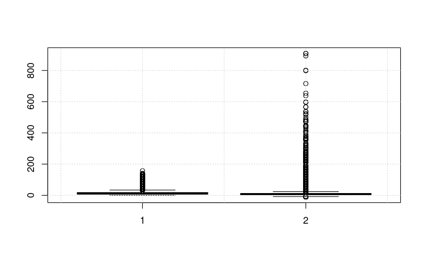

```r
boxplot(x0, x1)
grid()
```

Huh? Did somebody step on the boxes? It’s hard to see what’s going on here. There are so many values outside the boxes and the range of x1 is so big that the boxes are flattened. It might be more informative to call boxplot on the logs (base 10) of x0 and x1. Do this now using log10(x0) and log10(x1) as the 2 arguments.

```r
boxplot(log10(x0), log10(x1))
```

```
Warning in boxplot.default(log10(x0), log10(x1)) : NaNs produced
Warning in bplt(at[i], wid = width[i], stats = z$stats[, i], out = z$out[z$group ==  :
  Outlier (-Inf) in boxplot 1 is not drawn
Warning in bplt(at[i], wid = width[i], stats = z$stats[, i], out = z$out[z$group ==  :
  Outlier (-Inf) in boxplot 2 is not drawn
```

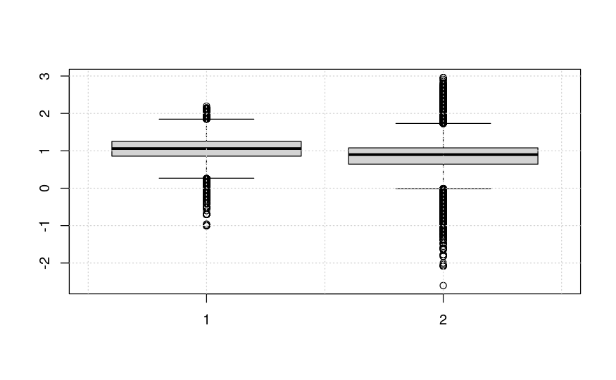

```r
grid()
```

A bonus! Not only do we get a better looking boxplot we also get some warnings from R in Red. These let us know that some values in x0 and x1 were “unloggable”, no doubt the 0 (Min) we saw in the summary of x0 and the negative values we saw in the Min of the summary of x1.

From the boxplot (x0 on the left and x1 on the right), what can you say about the data?

```r
"The median of x1 is less than the median of x0"
```

```
[1] "The median of x1 is less than the median of x0"
```

Let’s return to the question of the negative values in x1. Let’s count how many negative values there are. We’ll do this in a few steps.

First, form the vector negative by assigning to it the boolean x1<0.

```r
negative <- x1 < 0
```

Now run the R command sum with 2 arguments. The first is negative, and the second is na.rm set equal to TRUE. This tells sum to ignore the missing values in negative.

```r
sum(negative, na.rm=TRUE)
```

```
[1] 26474
```

So there are over 26000 negative values. Sounds like a lot. Is it? Run the R command mean with same 2 arguments you just used with the call to sum. This will tell us a percentage.

```r
mean(negative, na.rm=TRUE)
```

```
[1] 0.0215034
```

We see that just 2% of the x1 values are negative. Perhaps that’s a small enough percentage that we can ignore them. Before we ignore them, though, let’s see if they occur during certain times of the year.

First create the array dates by assigning to it the Date component of pm1. Remember to use the x$y notation.

```r
dates <- pm1$Date
```

To see what dates looks like run the R command str on it.

```r
str(dates)
```

```
 int [1:1304287] 20120101 20120104 20120107 20120110 20120113 20120116 20120119 20120122 20120125 20120128 ...
```

We see dates is a very long vector of integers. However, the format of the entries is hard to read. There’s no separation between the year, month, and day. Reassign to dates the output of a call to as.Date with the 2 arguments as.character(dates) as the first argument and the string “%Y%m%d” as the second.

```r
dates <- as.Date(as.character(dates), "%Y%m%d")
```

Now when you run head on dates you’ll see the dates in a nicer format. Try this now.

```r
head(dates)
```

```
[1] "2012-01-01" "2012-01-04" "2012-01-07" "2012-01-10" "2012-01-13" "2012-01-16"
```

Let’s plot a histogram of the months when the particulate matter measurements are negative. Run hist with 2 arguments. The first is dates[negative] and the second is the string “month”.

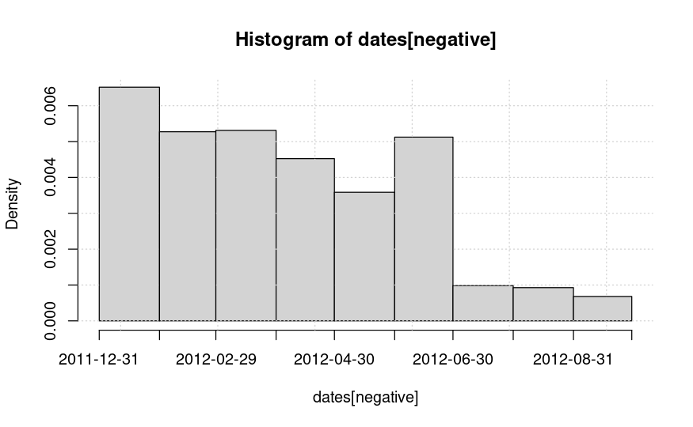

```r
hist(dates[negative], "month")
grid()
```

Now we’ll change focus a bit and instead of looking at all the monitors throughout the country and the data they recorded, we’ll try to find one monitor that was taking measurements in both 1999 and 2012. This will allow us to control for different geographical and environmental variables that might have affected air quality in different areas. We’ll narrow our search and look just at monitors in New York State.

```r
site0 <- unique(subset(pm0, State.Code == 36, c(County.Code, Site.ID)))
site1 <- unique(subset(pm1, State.Code == 36, c(County.Code, Site.ID)))
site0 <- paste(site0[,1], site0[,2], sep=".")
site1 <- paste(site1[,1], site1[,2], sep=".")
```

We subsetted off the New York State monitor identification data for 1999 and 2012 into 2 vectors, site0 and site1. Look at the structure of site0 now with the R command str.

```r
str(site0)
```

```
 chr [1:33] "1.5" "1.12" "5.73" "5.80" "5.83" "5.110" "13.11" "27.1004" "29.2" "29.5" "29.1007" ...
```

We see that site0 (the IDs of monitors in New York State in 1999) is a vector of 33 strings, each of which has the form “x.y”. We’ve created these from the county codes (the x portion of the string) and the monitor IDs (the y portion). If you ran str on site1 you’d see 18 similar values.

Use the intersect command with site0 and site1 as arguments and put the result in the variable both.

```r
both <- intersect(site0, site1)
```

Take a look at both now.

```r
both
```

```
 [1] "1.5"     "1.12"    "5.80"    "13.11"   "29.5"    "31.3"    "63.2008" "67.1015" "85.55"   "101.3"
```

We see that 10 monitors in New York State were active in both 1999 and 2012.

```r
pm0$county.site <- with(pm0, paste(County.Code, Site.ID, sep="."))
pm1$county.site <- with(pm1, paste(County.Code, Site.ID, sep="."))
```

To save you some time and typing, we modified the data frames pm0 and pm1 slightly by adding to each of them a new component, county.site. This is just a concatenation of two original components County.Code and Site.ID. We did this to facilitate the next step which is to find out how many measurements were taken by the 10 New York monitors working in both of the years of interest. Run head on pm0 to see the first few entries now.

```r
head(pm0)
```

|  | State.Code | County.Code | Site.ID | Date | Sample.Value | county.site |
| --- | --- | --- | --- | --- | --- | --- |
| 1 | 1 | 27 | 1 | 19990103 | NA | 27.1 |
| 2 | 1 | 27 | 1 | 19990106 | NA | 27.1 |
| 3 | 1 | 27 | 1 | 19990109 | NA | 27.1 |
| 4 | 1 | 27 | 1 | 19990112 | 8.841 | 27.1 |
| 5 | 1 | 27 | 1 | 19990115 | 14.920 | 27.1 |
| 6 | 1 | 27 | 1 | 19990118 | 3.878 | 27.1 |

Now pm0 and pm1 have 6 columns instead of 5, and the last column is a concatenation of two other columns, County and Site.

Now let’s see how many measurements each of the 10 New York monitors that were active in both 1999 and 2012 took in those years. We’ll create 2 subsets (one for each year), one of pm0 and the other of pm1.

The subsets will filter for 2 characteristics. The first is State.Code equal to 36 (the code for New York), and the second is that the county.site (the component we added) is in the vector both.

First create the variable cnt0 by assigning to it the output of the R command subset, called with 2 arguments. The first is pm0, and the second is a boolean with the 2 conditions we just mentioned. Recall that the testing for equality in a boolean requires ==, intersection of 2 boolean conditions is denoted by & and membership by %in%.

```r
cnt0 <- subset(pm0, State.Code == 36 & county.site %in% both)
```

Recall the last command with the up arrow, and create cnt1 (instead of cnt0). Remember to change pm0 to pm1. Everything else can stay the same.

```r
cnt1 <- subset(pm1, State.Code == 36 & county.site %in% both)
```

Now run the command sapply(split(cnt0, cnt0$county.site), nrow). This will split cnt0 into several data frames according to county.site (that is, monitor IDs) and tell us how many measurements each monitor recorded.

```r
sapply(split(cnt0, cnt0$county.site), nrow)
```

```
   1.12     1.5   101.3   13.11    29.5    31.3    5.80 63.2008 67.1015   85.55
     61     122     152      61      61     183      61     122     122       7
```

Do the same for cnt1. (Recall your last command and change 2 occurrences of cnt0 to cnt1.)

```r
sapply(split(cnt1, cnt1$county.site), nrow)
```

```
   1.12     1.5   101.3   13.11    29.5    31.3    5.80 63.2008 67.1015   85.55
     31      64      31      31      33      15      31      30      31      31
```

From the output of the 2 calls to sapply, which monitor is the only one whose number of measurements increased from 1999 to 2012?

```r
"85.55"
```

```
[1] "85.55"
```

We want to examine a monitor with a reasonable number of measurements so let’s look at the monitor with ID 63.2008. Create a variable pm0sub which is the subset of cnt0 (this contains just New York data) which has County.Code equal to 63 and Site.ID 2008.

```r
pm0sub <- subset(cnt0, County.Code==63 & Site.ID==2008)
```

Now do the same for cnt1. Name this new variable pm1sub.

```r
pm1sub <- subset(cnt1, County.Code==63 & Site.ID==2008)
```

From the output of the 2 calls to sapply, how many rows will pm0sub have?

```r
"122"
```

```
[1] "122"
```

Now we’d like to compare the pm25 measurements of this particular monitor (63.2008) for the 2 years. First, create the vector x0sub by assigning to it the Sample.Value component of pm0sub.

```r
x0sub <- pm0sub$Sample.Value
```

Similarly, create x1sub from pm1sub.

```r
x1sub <- pm1sub$Sample.Value
```

We’d like to make our comparison visually so we’ll have to create a time series of these pm25 measurements. First, create a dates0 variable by assigning to it the output of a call to as.Date. This will take 2 arguments. The first is a call to as.character with pm0sub$Date as the argument. The second is the format string “%Y%m%d”.

```r
dates0 <- as.Date(as.character(pm0sub$Date), "%Y%m%d")
```

Do the same for the 2012 data. Specifically, create dates1 using pm1sub$Date as your input.

```r
dates1 <- as.Date(as.character(pm1sub$Date), "%Y%m%d")
```

Now we’ll plot these 2 time series in the same panel using the base plotting system. Call par with 2 arguments. The first is mfrow set equal to c(1,2). This will tell the system we’re plotting 2 graphs in 1 row and 2 columns. The second argument will adjust the panel’s margins. It is mar set to c(4,4,2,1).

```r
par(mfrow=c(1, 2), mar=c(4, 4, 2, 1))
```

Call plot with the 3 arguments dates0, x0sub, and pch set to 20. The first two arguments are the x and y coordinates. This will show the pm25 values as functions of time.

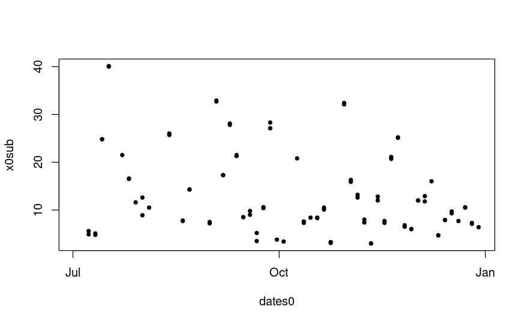

```r
plot(dates0, x0sub, pch=20)
```

Now we’ll mark the median.

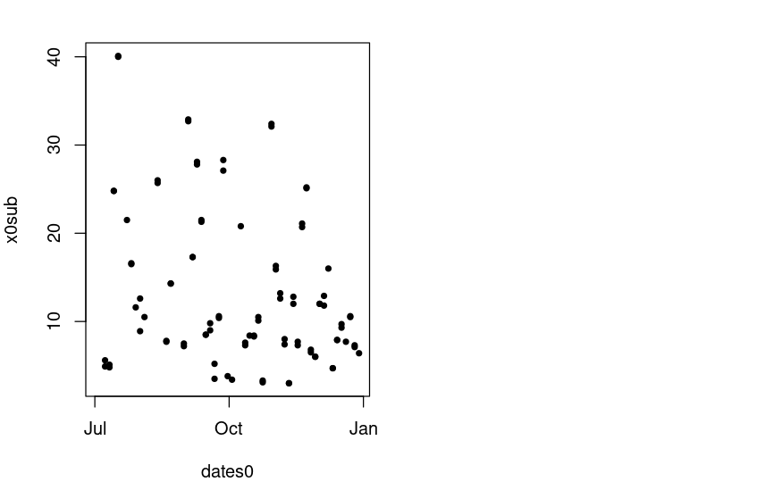

```r
try(dev.off(), silent=TRUE)
par(mfrow=c(1, 2), mar=c(4, 4, 2, 1))
plot(dates0, x0sub, pch=20)
```

Use abline to add a horizontal line at the median of the pm25 values. Make the line width 2 (lwd is the argument), and when you call median with x0sub, specify the argument na.rm to be TRUE.

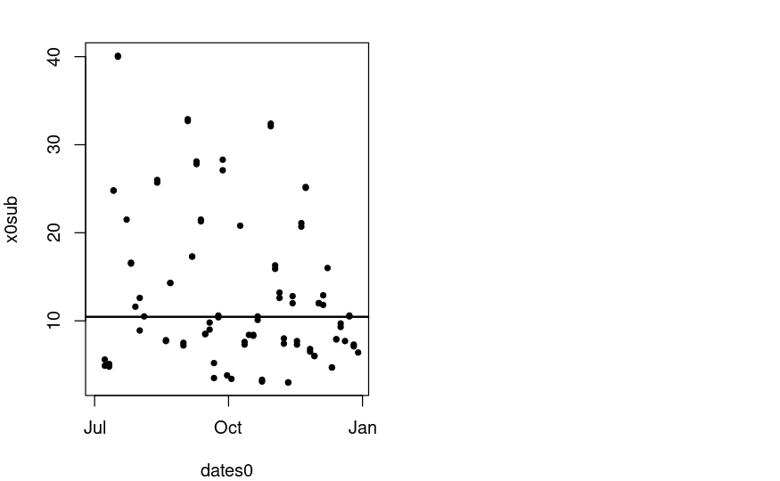

```r
try(dev.off(), silent=TRUE)
par(mfrow=c(1, 2), mar=c(4, 4, 2, 1))
plot(dates0, x0sub, pch=20)
abline(h=median(x0sub, na.rm=TRUE), lwd=2)
```

Now we’ll do the same for the 2012 data. Call plot with the 3 arguments dates1, x1sub, and pch set to 20.

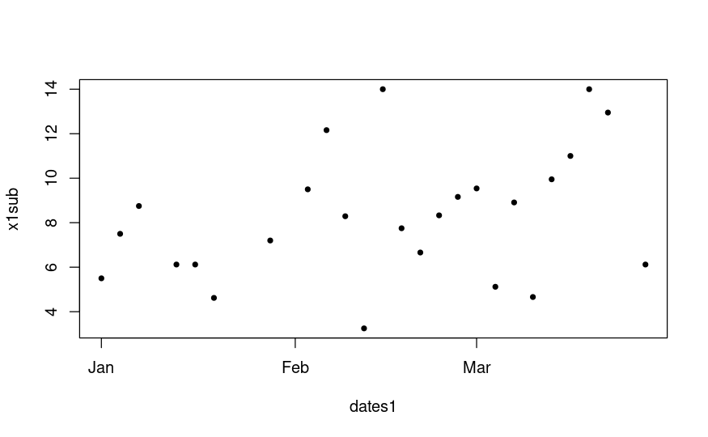

```r
plot(dates1, x1sub, pch=20)
```

As before, we’ll mark the median of this 2012 data.

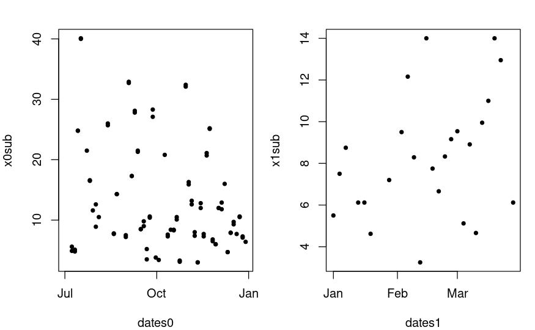

```r
try(dev.off(), silent=TRUE)
par(mfrow=c(1, 2), mar=c(4, 4, 2, 1))
plot(dates0, x0sub, pch=20)
plot(dates1, x1sub, pch=20)
```

Use abline to add a horizontal line at the median of the pm25 values. Make the line width 2 (lwd is the argument). Remember to specify the argument na.rm to be TRUE when you call median on x1sub.

```r
try(dev.off(), silent=TRUE)
par(mfrow=c(1, 2), mar=c(4, 4, 2, 1))
plot(dates0, x0sub, pch=20)
plot(dates1, x1sub, pch=20)
```

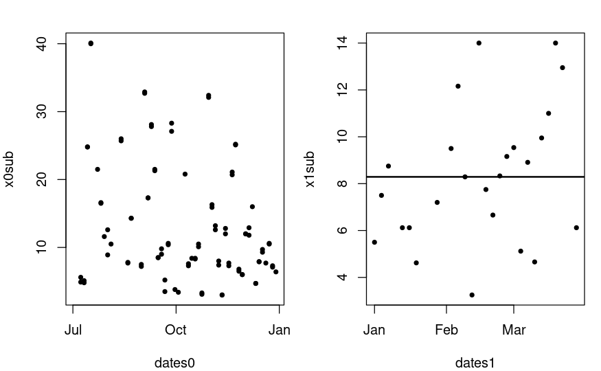

```r
abline(h=median(x1sub, na.rm=TRUE), lwd=2)
```

Which median is larger - the one for 1999 or the one for 2012?

```r
"1999"
```

```
[1] "1999"
```

The picture makes it look like the median is higher for 2012 than 1999. Closer inspection shows that this isn’t true. The median for 1999 is a little over 10 micrograms per cubic meter and for 2012 its a little over 8. The plots appear this way because the 1999 plot ….

```r
"shows a bigger range of y values than the 2012 plot"
```

```
[1] "shows a bigger range of y values than the 2012 plot"
```

The 1999 plot shows a much bigger range of pm25 values on the y axis, from below 10 to 40, while the 2012 pm25 values are much more restricted, from around 1 to 14. We should really plot the points of both datasets on the same range of values on the y axis. Create the variable rng by assigning to it the output of a call to the R command range with 3 arguments, x0sub, x1sub, and the boolean na.rm set to TRUE.

```r
rng <- range(x0sub, x1sub, na.rm=TRUE)
```

Look at rng to see the values it spans.

```r
rng
```

```
[1]  3.0 40.1
```

Here a new figure we’ve created showing the two plots side by side with the same range of values on the y axis. We used the argument ylim set equal to rng in our 2 calls to plot. The improvement in the medians between 1999 and 2012 is now clear. Also notice that in 2012 there are no big values (above 15). This shows that not only is there a chronic improvement in air quality, but also there are fewer days with severe pollution.

```r
par(mfrow=c(1, 2), mar=c(4, 4, 2, 1))
plot(dates0, x0sub, pch=20, ylim=rng)
abline(h=median(x0sub, na.rm=TRUE), lwd=2)
```

```r
plot(dates1, x1sub, pch=20, ylim=rng)
abline(h=median(x1sub, na.rm=TRUE), lwd=2)
```

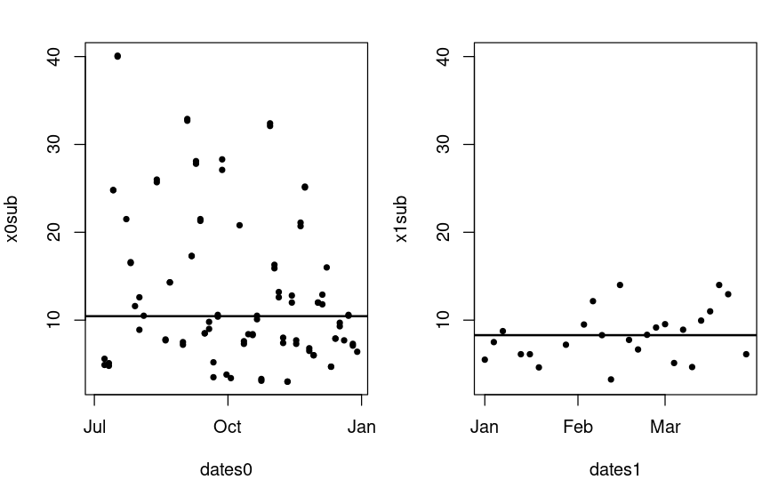

```r
par(mfrow=c(1, 1))
```

The last avenue of this data we’ll explore (and we’ll do it quickly) concerns a comparison of all the states’ mean pollution levels. This is important because the states are responsible for implementing the regulations set at the federal level by the EPA.

Let’s first gather the mean (average measurement) for each state in 1999. Recall that the original data for this year was stored in pm0.

Create the vector mn0 with a call to the R command with using 2 arguments. The first is pm0. This is the data in which the second argument, an expression, will be evaluated. The second argument is a call to the function tapply. This call requires 4 arguments. Sample.Value and State.Code are the first two. We want to apply the function mean to Sample.Value, so mean is the third argument. The fourth is simply the boolean na.rm set to TRUE.

```r
mn0 <- with(pm0, tapply(Sample.Value, State.Code, mean, na.rm=TRUE))
```

Call the function str with mn0 as its argument to see what it looks like.

```r
str(mn0)
```

```
 num [1:53(1d)] 19.96 6.67 10.8 15.68 17.66 ...
 - attr(*, "dimnames")=List of 1
  ..$ : chr [1:53] "1" "2" "4" "5" ...
```

We see mn0 is a 53 long numerical vector. Why 53 if there are only 50 states? As it happens, pm25 measurements for the District of Columbia (Washington D.C), the Virgin Islands, and Puerto Rico are included in this data. They are coded as 11, 72, and 78 respectively.

Recall your command creating mn0 and change it to create mn1 using pm1 as the first input to the call to with.

```r
mn1 <- with(pm1, tapply(Sample.Value, State.Code, mean, na.rm=TRUE))
```

For fun, call the function str with mn1 as its argument.

```r
str(mn1)
```

```
 num [1:52(1d)] 10.13 4.75 8.61 10.56 9.28 ...
 - attr(*, "dimnames")=List of 1
  ..$ : chr [1:52] "1" "2" "4" "5" ...
```

So mn1 has only 52 entries, rather than 53. We checked. There are no entries for the Virgin Islands in 2012. Call summary now with mn0 as its input.

```r
summary(mn0)
```

```
   Min. 1st Qu.  Median    Mean 3rd Qu.    Max.
  4.862   9.519  12.315  12.406  15.640  19.956
```

Now call summary with mn1 as its input so we can compare the two years.

```r
summary(mn1)
```

```
   Min. 1st Qu.  Median    Mean 3rd Qu.    Max.
  4.006   7.355   8.729   8.759  10.613  11.992
```

We see that in all 6 entries, the 2012 numbers are less than those in 1999. Now we’ll create 2 new dataframes containing just the state names and their mean measurements for each year. First, we’ll do this for 1999. Create the data frame d0 by calling the function data.frame with 2 arguments. The first is state set equal to names(mn0), and the second is mean set equal to mn0.

```r
d0 <- data.frame(state = names(mn0), mean = mn0)
```

Recall the last command and create d1 instead of d0 using the 2012 data. (There’ll be 3 changes of 0 to 1.)

```r
d1 <- data.frame(state = names(mn1), mean = mn1)
```

Create the array mrg by calling the R command merge with 3 arguments, d0, d1, and the argument by set equal to the string “state”.

```r
mrg <- merge(d0, d1, by = "state")
```

Run dim with mrg as its argument to see how big it is.

```r
dim(mrg)
```

```
[1] 52  3
```

We see merge has 52 rows and 3 columns. Since the Virgin Island data was missing from d1, it is excluded from mrg. Look at the first few entries of mrg using the head command.

```r
head(mrg)
```

|  | state | mean.x | mean.y |
| --- | --- | --- | --- |
| 1 | 1 | 19.956391 | 10.126190 |
| 2 | 10 | 14.492895 | 11.236059 |
| 3 | 11 | 15.786507 | 11.991697 |
| 4 | 12 | 11.137139 | 8.239690 |
| 5 | 13 | 19.943240 | 11.321364 |
| 6 | 15 | 4.861821 | 8.749336 |

Each row of mrg has 3 entries - a state identified by number, a state mean for 1999 (mean.x), and a state mean for 2012 (mean.y).

Now we’ll plot the data to see how the state means changed between the 2 years. First we’ll plot the 1999 data in a single column at x=1. The y values for the points will be the state means. Again, we’ll use the R command with so we don’t have to keep typing mrg as the data environment in which to evaluate the second argument, the call to plot. We’ve already reset the graphical parameters for you.

For the first column of points, call with with 2 arguments. The first is mrg, and the second is the call to plot with 3 arguments. The first of these is rep(1,52). This tells the plot routine that the x coordinates for all 52 points are 1. The second argument is the second column of mrg or mrg[,2] which holds the 1999 data. The third argument is the range of x values we want, namely xlim set to c(.5,2.5). This works since we’ll be plotting 2 columns of points, one at x=1 and the other at x=2.

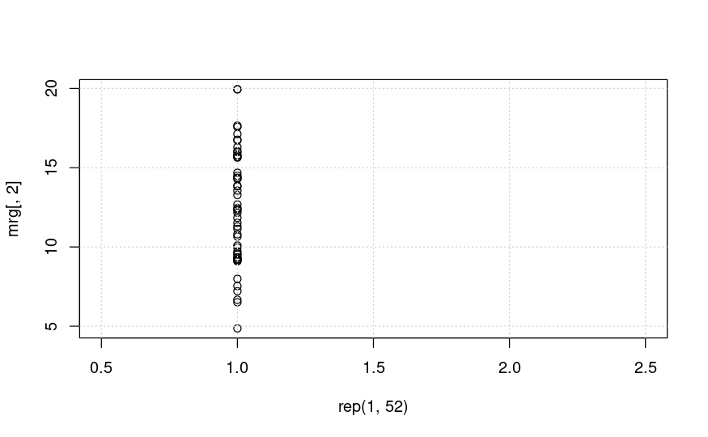

```r
with(mrg, plot(rep(1, 52), mrg[, 2], xlim = c(.5, 2.5)))
grid()
```

We see a column of points at x=1 which represent the 1999 state means. For the second column of points, again call with with 2 arguments. As before, the first is mrg. The second, however, is a call to the function points with 2 arguments. We need to do this since we’re adding points to an already existing plot. The first argument to points is the set of x values, rep(2,52). The second argument is the set of y values, mrg[,3]. Of course, this is the third column of mrg. (We don’t need to specify the range of x values again.)

```r
with(mrg, plot(rep(1, 52), mrg[, 2], xlim = c(.5, 2.5)))
with(mrg, points(rep(2, 52), mrg[, 3]))
```

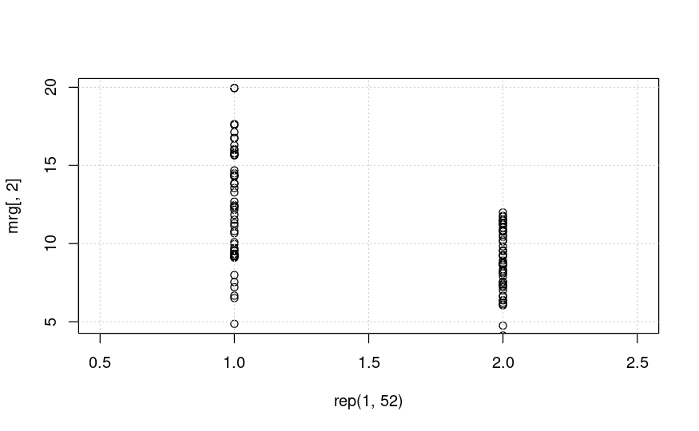

```r
grid()
```

We see a shorter column of points at x=2. Now let’s connect the dots. Use the R function segments with 4 arguments. The first 2 are the x and y coordinates of the 1999 points and the last 2 are the x and y coordinates of the 2012 points. As in the previous calls specify the x coordinates with calls to rep and the y coordinates with references to the appropriate columns of mrg.

```r
with(mrg, plot(rep(1, 52), mrg[, 2], xlim=c(.5, 2.5)))
with(mrg, points(rep(2, 52), mrg[, 3]))
```

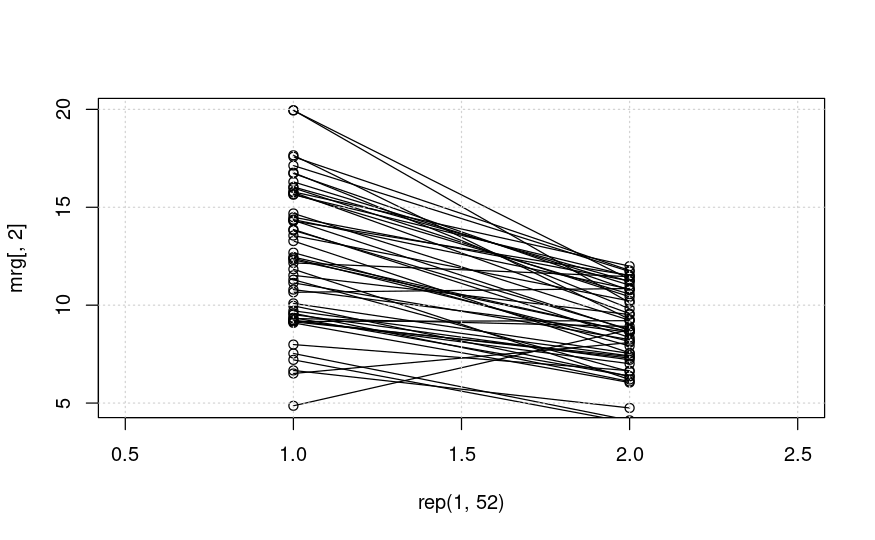

```r
segments(rep(1, 52), mrg[, 2], rep(2, 52), mrg[, 3])
grid()
```

We see from the plot that the vast majority of states have indeed improved their particulate matter counts so the general trend is downward. There are a few exceptions. (The topmost point in the 1999 column is actually two points that had very close measurements.)

For fun, let’s see which states had higher means in 2012 than in 1999. Just use the mrg[mrg$mean.x < mrg$mean.y, ] notation to find the rows of mrg with this particulate property.

```r
mrg[mrg$mean.x < mrg$mean.y,]
```

|  | state | mean.x | mean.y |
| --- | --- | --- | --- |
| 6 | 15 | 4.861821 | 8.749336 |
| 23 | 31 | 9.167770 | 9.207489 |
| 27 | 35 | 6.511285 | 8.089755 |
| 33 | 40 | 10.657617 | 10.849870 |

Only 4 states had worse pollution averages, and 2 of these had means that were very close. If you want to see which states (15, 31, 35, and 40) these are, you can check out this website https://www.epa.gov/enviro/state-fips-code-listing to decode the state codes.

This concludes the lesson, comparing air pollution data from two years in different ways. First, we looked at measures of the entire set of monitors, then we compared the two measures from a particular monitor, and finally, we looked at the mean measures of the individual states.